# Time Series Analysis

```r
library(tidyverse)
library(fUnitRoots)
library(forecast)
library(tseries)


unemploy =
  read_csv("Unemployment.csv") %>%
  separate(label, into = c("year", "month")) %>%
  dplyr::filter(year != 2017)

unemploy = dplyr::rename(unemploy, state = series_id)

gun_violence =
  read_csv("data/year_month_state_massshooting.csv") %>%
  mutate(year = year + 2000) %>%
  mutate(year = as.character(year))


new_dataframe =
  left_join(unemploy, gun_violence, by = c("state" = "state", "year" = "year", "month" = "month")) %>%
  select(-...1, -period) %>%
  mutate(number_mass_shooting = replace(number_mass_shooting, is.na(number_mass_shooting),  0))

illinois =
  new_dataframe %>%
  dplyr::filter(state == "Illinois") %>%
  dplyr::select(number_mass_shooting)
```

The data used in our time series analysis is from 2018-2021 in Illinois. It records the average number of mass shooting in each month within the time period. We want to use those data to forecast the pattern of mass shooting in 2022 in Illinois.

## Trend and seasonality exploration

First, let’s see the general trend and seasonality of our data between 2018-2021 and generate the time series. From the plot below, we can see a general increase in the number of mass shooting throughout 2018-2021, and there seems to be a seasonality within each year.

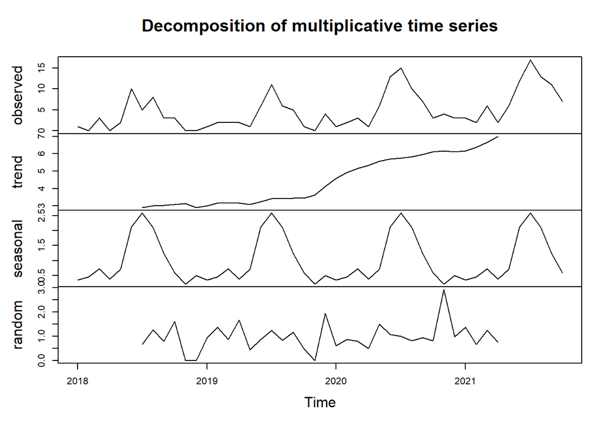

```r
month.ts = ts(illinois, start = 2018, frequency = 12)
plot(decompose(month.ts, type = "multiplicative"))
```

## Transformation and necessary tests

Then, we did a box-cox transformation to make the variance equal. Because the lambda we got is 0.4744096, we decided to square root our series according to the common powers in box-cox transformation. and the new lambda we got is 1.0820651. It is close to one, which means our series have an equal variance now.

```r
lambda <- BoxCox.lambda(month.ts)
d1 = sqrt(month.ts)
BoxCox.lambda(d1)
```

```
## [1] 1.082065
```

```r
## reject null hypothesis, therefore it is stationary
adf.test(d1)

Box.test(d1, type = "Ljung-Box", lag = 6)
Box.test(d1, type = "Ljung-Box", lag = 12)
Box.test(d1, type = "Ljung-Box", lag = 18)
Box.test(d1, type = "Ljung-Box", lag = 24)
## reject null hypothesis, therefore not white noise
```

[output not shown]

## Model Selection

Next, we examined the ACF and PACF plot.

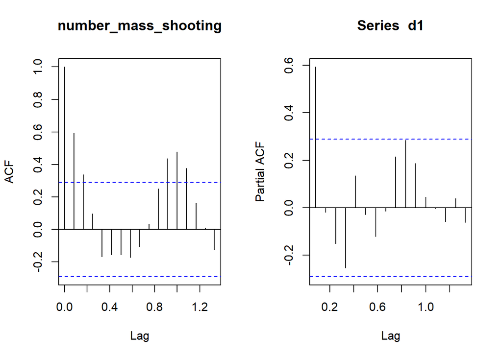

```r
par(mfrow = c(1,2))
acf(d1)
##acf(d1, plot = F)
pacf(d1)
```

```r
##pacf(d1, plot = F)
```

We could observe a sharp cut off at lag 1 in our PACF graph, and a gradual decrease in ACF plot, but the spikes become significant at lag 11-13. To figure out which ARIMA model to use, we decide to use the function auto.arima. It tells us that we should use ARIMA(0,0,1)(1,1,0)[12].

```r
fit_auto = auto.arima(d1)
```

## Residual check

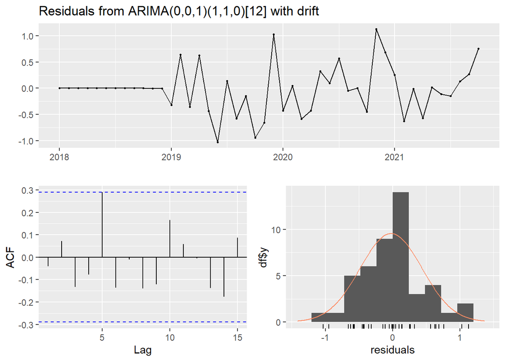

```r
checkresiduals(auto.arima(d1))## Residuals are white noise
```

## Forecast plot

Finally, we drew the forecast plot for the number of mass shooting in Illinois in 2022. From the plot, we could observe that in 2022, the number of mass shooting in Illinois is highly likely to continue increasing in general and it will follow the seasonal pattern that more mass shooting incidents may occur in the middle of the year.

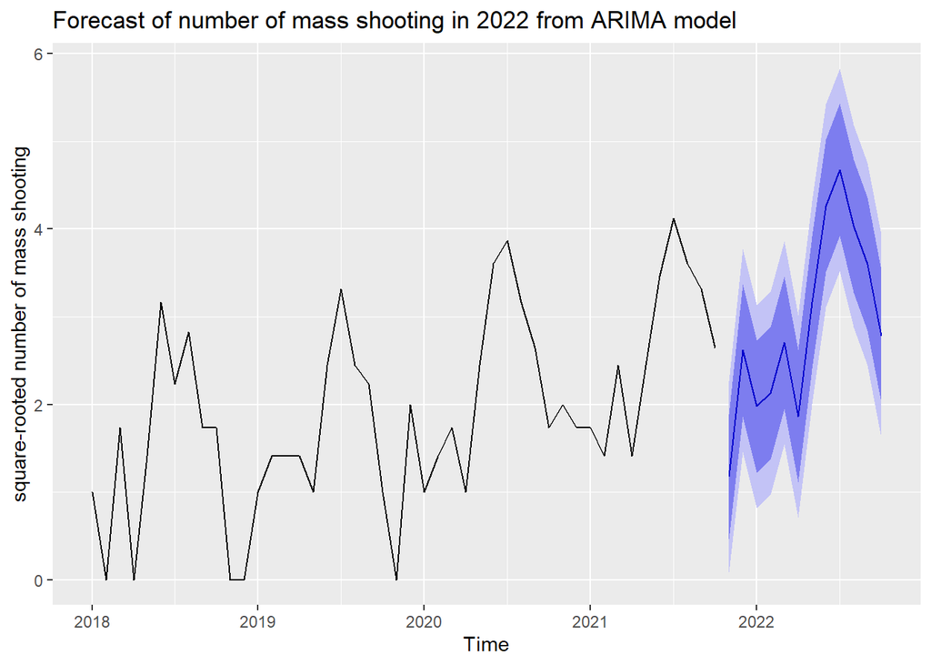

```r
d1 %>%
  auto.arima() %>%
  forecast(h = 12) %>%
  autoplot(ylab = "square-rooted number of mass shooting", main = "Forecast of number of mass shooting in 2022 from ARIMA model")
```